# Goal of Collecting this Dataset

The goal of collecting a Hepatitis C Virus (HCV) dataset To uncover novel knowledge and insights about HCV in Egyptian patients that may not be immediately apparent by understanding the progress of HCV in infected individuals. Data mining plays an essential role in the knowledge discovery process techniques which can be used to analyze how the disease evolves over time and what factors contribute to its progression.

# Dataset

The dataset was sourced from the uci website in this URL : http://archive.ics.uci.edu/dataset/503/hepatitis+c+virus+hcv+for+egyptian+patients

# General Information

- Number of Attributes: 28

- Number of Objects: 1385

- Type of Attributes: Numeric, Nominal,Ordinal

-The goal of collecting a Hepatitis C Virus (HCV) dataset is to uncover novel knowledge and insights about HCV in Egyptian patients that may not be immediately apparent. This dataset serves a dual purpose: First, it allows us to classify patients into different categories based on various factors, providing a deeper understanding of the disease’s progression and its impact on individuals. Second, through clustering techniques, we aim to identify distinct patient groups with similar characteristics, allowing for the development of personalized treatment strategies and better disease management. Data mining techniques play an essential role in the knowledge discovery process, helping us analyze the disease’s evolution over time and determine the factors contributing to its progression and impact on different patient groups

- Features names:Age,Gender,BMI(Body Mass Index),Nausea/Vomting, Diarrhea, Fever, Headache,Fatigue & generalized bone ache, Jaundice, Epigastric pain, WBC(White blood cells),RBC(Red blood cells),HGB(Hemoglobin),Plat(Platelets), AST 1(aspartate transaminase ratio),ALT1(alanine transaminase ratio 1 week),ALT4(alanine transaminase ratio 4 weeks), ALT 12(alanine transaminase ratio 12 weeks), ALT 24(alanine transaminase ratio 24 weeks), ALT 36(alanine transaminase ratio 36 weeks ),ALT 48(alanine transaminase ratio 48 weeks), ALT after 24 w(after 24 warnings alanine transaminase ratio 24 weeks), RNA Base, RNA 4, RNA 12, RNA EOT(RNA end-of-treatment),RNA EF(RNA Elongation Factor), Baseline histological Grading, Baselinehistological staging.

```r
# Install and load necessary packages
dataset <- read.csv('HCV-Egy-Data.csv')


# Install and load necessary packages
if(!require(Hmisc)){
 install.packages("Hmisc")  # Install the Hmisc package
    }
library("Hmisc")    # Load the Hmisc package
```

```r
 describe(dataset)
```

```
## dataset
##
##  29  Variables      1385  Observations
## --------------------------------------------------------------------------------
## Age
##        n  missing distinct     Info     Mean      Gmd      .05      .10
##     1385        0       30    0.999    46.32    10.14       33       34
##      .25      .50      .75      .90      .95
##       39       46       54       58       60
##
## lowest : 32 33 34 35 36, highest: 57 58 59 60 61
## --------------------------------------------------------------------------------
## Gender
##        n  missing distinct     Info     Mean      Gmd
##     1385        0        2     0.75     1.49   0.5001
##
## Value         1    2
## Frequency   707  678
## Proportion 0.51 0.49
## --------------------------------------------------------------------------------
## BMI
##        n  missing distinct     Info     Mean      Gmd      .05      .10
##     1385        0       14    0.995    28.61    4.695       22       23
##      .25      .50      .75      .90      .95
##       25       29       32       34       35
##
## Value         22    23    24    25    26    27    28    29    30    31    32
## Frequency     96    97   112    92    78    99   107    93    95   104    90
## Proportion 0.069 0.070 0.081 0.066 0.056 0.071 0.077 0.067 0.069 0.075 0.065
##
## Value         33    34    35
## Frequency    104   118   100
## Proportion 0.075 0.085 0.072
##
## For the frequency table, variable is rounded to the nearest 0
## --------------------------------------------------------------------------------
## Fever
##        n  missing distinct     Info     Mean      Gmd
##     1385        0        2    0.749    1.516   0.4999
##
```

[output cut: 205 more lines]

```
## Frequency    106   139    86
## Proportion 0.077 0.100 0.062
##
## For the frequency table, variable is rounded to the nearest 0
## --------------------------------------------------------------------------------
## Baselinehistological.staging
##        n  missing distinct     Info     Mean      Gmd
##     1385        0        4    0.937    2.536    1.254
##
## Value          1     2     3     4
## Frequency    336   332   355   362
## Proportion 0.243 0.240 0.256 0.261
##
## For the frequency table, variable is rounded to the nearest 0
## --------------------------------------------------------------------------------
```

# Data Structure

the function str will help to understand the internal structure of the project Data name, variables and objects numbers, Dimension, Data Values (provided a preview of the first few data values for each variable)

```r
# Explore dataset structure
str(dataset)
```

```
## 'data.frame':    1385 obs. of  29 variables:
##  $ Age                            : int  56 46 57 49 59 58 42 48 44 45 ...
##  $ Gender                         : int  1 1 1 2 1 2 2 2 1 1 ...
##  $ BMI                            : int  35 29 33 33 32 22 26 30 23 30 ...
##  $ Fever                          : int  2 1 2 1 1 2 1 1 1 2 ...
##  $ Nausea.Vomting                 : int  1 2 2 2 1 2 1 1 1 1 ...
##  $ Headache                       : int  1 2 2 1 2 2 2 2 2 2 ...
##  $ Diarrhea                       : int  1 1 2 2 1 1 2 2 2 2 ...
##  $ Fatigue...generalized.bone.ache: int  2 2 1 1 2 2 2 1 2 1 ...
##  $ Jaundice                       : int  2 2 1 2 2 2 2 1 1 1 ...
##  $ Epigastric.pain                : int  2 1 1 1 2 1 2 2 2 2 ...
##  $ WBC                            : int  7425 12101 4178 6490 3661 11785 11620 7335 10480 6681 ...
##  $ RBC                            : num  4248807 4429425 4621191 4794631 4606375 ...
##  $ HGB                            : int  14 10 12 10 11 15 12 11 12 12 ...
##  $ Plat                           : num  112132 129367 151522 146457 187684 ...
##  $ AST.1                          : int  99 91 113 43 99 66 78 119 93 55 ...
##  $ ALT.1                          : int  84 123 49 64 104 104 57 112 83 68 ...
##  $ ALT4                           : num  52 95 95 109 67 121 113 80 55 72 ...
##  $ ALT.12                         : int  109 75 107 80 48 96 118 127 102 127 ...
##  $ ALT.24                         : int  81 113 116 88 120 65 107 45 97 81 ...
##  $ ALT.36                         : int  5 57 5 48 94 73 84 96 122 125 ...
##  $ ALT.48                         : int  5 123 5 77 90 114 80 53 39 43 ...
##  $ ALT.after.24.w                 : int  5 44 5 33 30 29 28 39 45 30 ...
##  $ RNA.Base                       : int  655330 40620 571148 1041941 660410 1157452 325694 641129 591441 1151206 ...
##  $ RNA.4                          : int  634536 538635 661346 449939 738756 1086852 1034008 72050 757361 230488 ...
##  $ RNA.12                         : int  288194 637056 5 585688 3731527 5 275095 787295 5 267320 ...
##  $ RNA.EOT                        : int  5 336804 735945 744463 338946 5 214566 370605 371090 275295 ...
##  $ RNA.EF                         : int  5 31085 558829 582301 242861 5 635157 506296 203042 555516 ...
##  $ Baseline.histological.Grading  : int  13 4 4 10 11 4 12 12 5 4 ...
##  $ Baselinehistological.staging   : int  2 2 4 3 1 4 4 3 2 2 ...
```

```r
# Display for first few rows
head(dataset)
```

```
##   Age Gender BMI Fever Nausea.Vomting Headache Diarrhea
## 1  56      1  35     2              1        1        1
## 2  46      1  29     1              2        2        1
## 3  57      1  33     2              2        2        2
## 4  49      2  33     1              2        1        2
## 5  59      1  32     1              1        2        1
## 6  58      2  22     2              2        2        1
##   Fatigue...generalized.bone.ache Jaundice Epigastric.pain   WBC     RBC HGB
## 1                               2        2               2  7425 4248807  14
## 2                               2        2               1 12101 4429425  10
## 3                               1        1               1  4178 4621191  12
## 4                               1        2               1  6490 4794631  10
## 5                               2        2               2  3661 4606375  11
## 6                               2        2               1 11785 3882456  15
##     Plat AST.1 ALT.1 ALT4 ALT.12 ALT.24 ALT.36 ALT.48 ALT.after.24.w RNA.Base
```

[output cut: 20 more lines]

```r
# Check for missing values
sum(is.na(dataset))
```

```
## [1] 0
```

No missing values in the data set

# Summary statistics

we choose three variables to show the Summary statistics for which (Age, Body mass index,RNA end-of-treatment )

```r
# Summary statistics for numerical variables
summary(dataset[c("Age", "BMI", "RNA.EOT")])
```

```
##       Age             BMI           RNA.EOT
##  Min.   :32.00   Min.   :22.00   Min.   :     5
##  1st Qu.:39.00   1st Qu.:25.00   1st Qu.:     5
##  Median :46.00   Median :29.00   Median :251376
##  Mean   :46.32   Mean   :28.61   Mean   :287660
##  3rd Qu.:54.00   3rd Qu.:32.00   3rd Qu.:517806
##  Max.   :61.00   Max.   :35.00   Max.   :808450
```

These statistics shows that for ‘Age’ : -The minimum infected age is 32 years. -The median age (50th percentile) is 46 years, meaning that 50% of the individuals are 46 years old or younger. -The mean age is approximately 46.32 years, providing the average age in the dataset. -The maximum age is 61 years, representing the oldest age in the dataset

for ‘BMI’ : -The minimum BMI is 22.

-The median BMI is 29, indicating that 50% of the individuals have a BMI of 29 or lower. -The mean BMI is approximately 28.61, providing the average BMI in the dataset.

-The maximum BMI is 35, representing the highest BMI in the dataset

for ‘RNA’ : -The minimum HCV RNA level at the end of treatment is 5.

-The median HCV RNA level is 251,376, meaning that 50% of the individuals have an HCV RNA level of 251,376 or lower at the end of treatment. -The mean HCV RNA level is approximately 287,660, providing the average HCV RNA level at the end of treatment.

-The maximum HCV RNA level at the end of treatment is 808,450, representing the highest value in the dataset.

# Class Label

The class label “Baselinehistological.staging” categorizes patients into four distinct stages, each representing a different level of the condition under study. These stages provide valuable insights into the distribution of patients across the disease’s progression. The pie chart below illustrates the distribution of patients among these stages:

```r
if(!require(vcd)){
 install.packages("vcd")  # Install the Hmisc package
    }
if(!require(grid)){
 install.packages("grid")  # Install the Hmisc package
    }
```

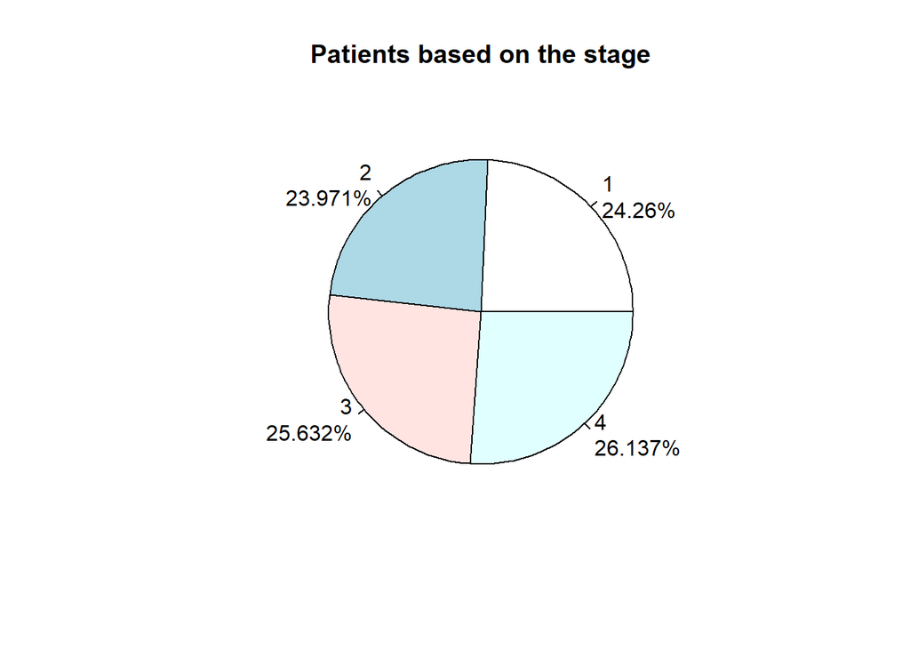

```r
# Read the data from the CSV file
data <-read.csv('HCV-Egy-Data.csv')


# Create the contingency table
contingency_table <- table(data$Baselinehistological.staging)

# Calculate percentages
percentages <- prop.table(contingency_table) * 100

# Round percentages to 3 decimal places
percentages <- round(percentages, 3)

# Create labels for the pie chart
labels <- paste0(names(contingency_table), '\n', percentages, '%')


# Create the pie chart
pie(contingency_table, labels = labels, main = "Patients based on the stage")
```

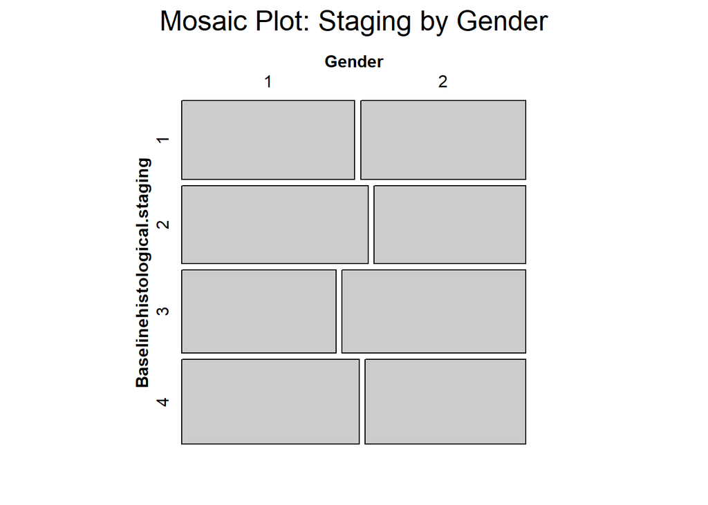

```r
# Load necessary libraries
library(vcd)

# Create a mosaic plot for 'Baselinehistological.staging' by 'Gender'
mosaic(~ Baselinehistological.staging + Gender, data = dataset, main = "Mosaic Plot: Staging by Gender")
```

Furthermore;

In the mosaic plot depicting the relationship between ‘Baselinehistological.staging’ and ‘Gender,’ we observe a difference in the diagnosis patterns between men and women, particularly in stages 2 and 3.

# Histogram for ‘Age’

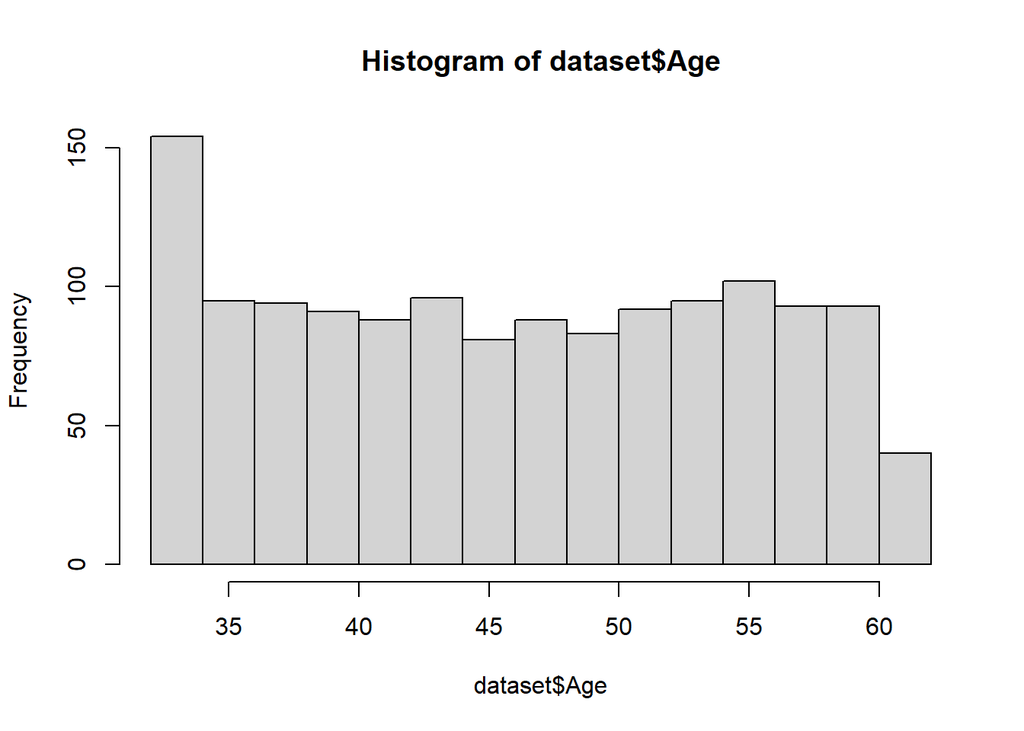

```r
# Histogram for a numerical variable 'Age'
hist(dataset$Age)
```

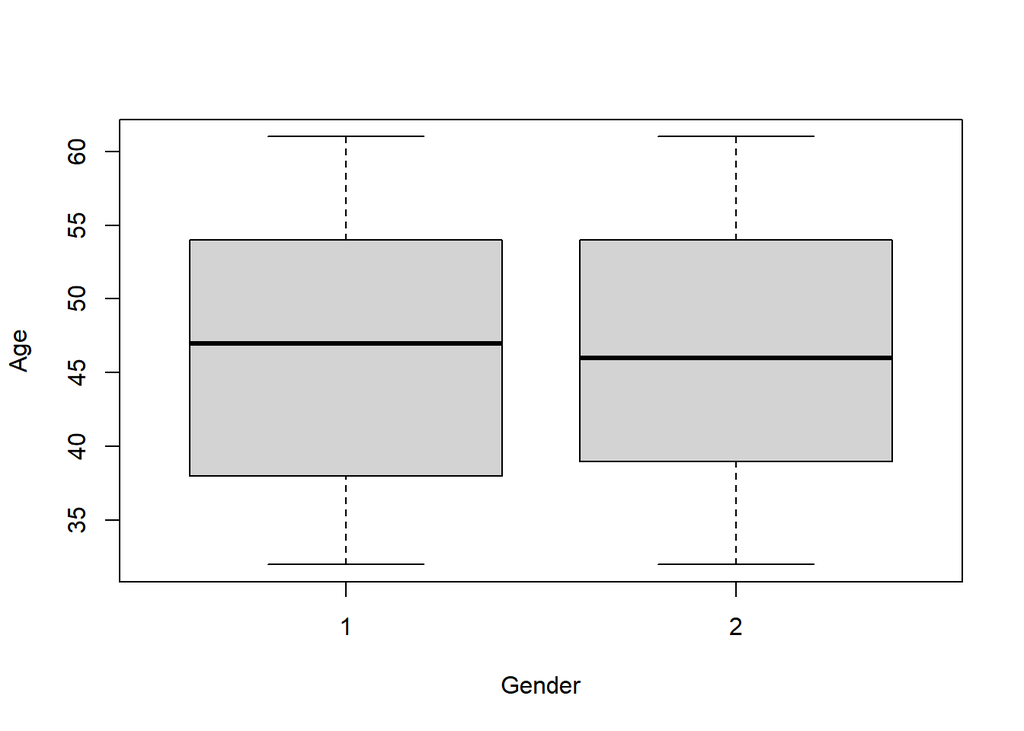

```r
#Boxplot for 'Age' by 'Gender'
boxplot(Age ~ Gender, data = dataset)
```

```r
if(!require(dplyr)){
 install.packages("dplyr")  # Install the dplyr package
    }
library("dplyr")    # Load the dplyr package
```

A pie chart that shows patients who were suffering from Headache

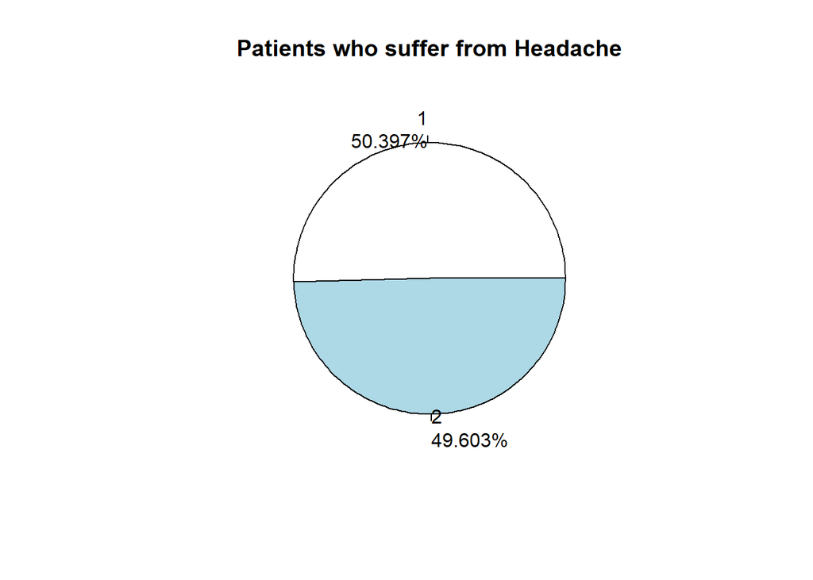

```r
# Read the data from the CSV file
data <-read.csv('HCV-Egy-Data.csv')


# Create the contingency table
contingency_table <- table(data$Headache)


# Calculate percentages
percentages <- prop.table(contingency_table) * 100

# Round percentages to 3 decimal places
percentages <- round(percentages, 3)

# Create labels for the pie chart
labels <- paste0(names(contingency_table), '\n', percentages, '%')

# Create the pie chart
pie(contingency_table, labels = labels, main = "Patients who suffer from Headache")
```

A pie chart that shows patients who were suffering from Fever

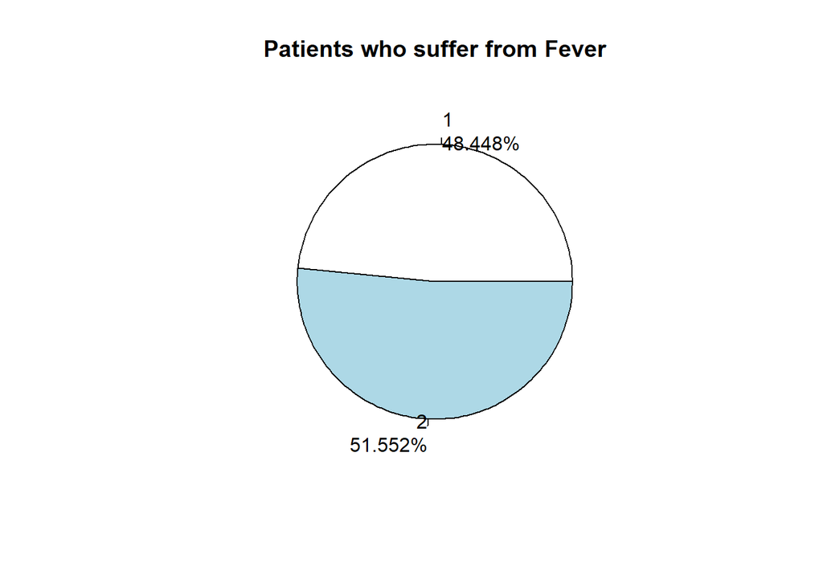

```r
# Read the data from the CSV file
data <-read.csv('HCV-Egy-Data.csv')

# Create a table of the 'Fever' column
tab <- table(data$Fever)

# Calculate percentages
percentages <- prop.table(tab) * 100

# Round percentages to 3 decimal places
percentages <- round(percentages, 3)

# Create labels for the pie chart
labels <- paste0(names(tab), '\n', percentages, '%')

# Create the pie chart
pie(tab, labels = labels, main = "Patients who suffer from Fever")
```

# In the pie charts

it’s evident that 50% of individuals infected with HCV are experiencing headaches. Additionally, the data reveals that 51.5% of individuals infected by the virus are experiencing fever. This high percentage indicates that both fever and headache are common symptoms associated with HCV infection

```r
# Print the dimensions of the dataset
dim(dataset)
```

```
## [1] 1385   29
```

```r
# Remove rows with missing values and print new dimensions
dataset = na.omit(dataset)
dim(dataset)
```

```
## [1] 1385   29
```

#Detecting outliers using boxplots

Outliers in a database are data points that stand out from the rest and don’t follow the usual pattern. They can cause problems in data analysis by making the results inaccurate or misleading. First, we identify all outliers for the numeric columns. Second, we deleted rows containing outliers. In our database we have 4 rows containing outliers.

```r
# Checking for outliers in various columns
boxplot.stats(dataset$Age)$out
```

```
## integer(0)
```

```r
boxplot.stats(dataset$BMI)$out
```

```
## integer(0)
```

```r
boxplot.stats(dataset$WBC)$out
```

```
## integer(0)
```

```r
boxplot.stats(dataset$RBC)$out
```

```
## numeric(0)
```

```r
boxplot.stats(dataset$HGB)$out
```

```
## integer(0)
```

```r
boxplot.stats(dataset$Plat)$out
```

```
## numeric(0)
```

```r
boxplot.stats(dataset$AST.1)$out
```

```
## integer(0)
```

```r
boxplot.stats(dataset$ALT.1)$out
```

```
## integer(0)
```

```r
boxplot.stats(dataset$ALT4)$out
```

```
## numeric(0)
```

```r
boxplot.stats(dataset$ALT.12)$out
```

```
## integer(0)
```

```r
boxplot.stats(dataset$ALT.24)$out
```

```
## integer(0)
```

```r
boxplot.stats(dataset$ALT.36)$out
```

```
## integer(0)
```

```r
boxplot.stats(dataset$ALT.48)$out
```

```
## integer(0)
```

```r
boxplot.stats(dataset$ALT.after.24.w)$out
```

```
## [1] 5 5 5
```

```r
boxplot.stats(dataset$RNA.Base)$out
```

```
## integer(0)
```

```r
boxplot.stats(dataset$RNA.4)$out
```

```
## integer(0)
```

```r
boxplot.stats(dataset$RNA.12)$out
```

```
## [1] 3731527
```

```r
boxplot.stats(dataset$RNA.EOT)$out
```

```
## integer(0)
```

```r
boxplot.stats(dataset$RNA.EF)$out
```

```
## integer(0)
```

```r
boxplot.stats(dataset$Baseline.histological.Grading)$out
```

```
## integer(0)
```

```r
# Removing outliers
# Remove outliers in the 'ALT.after.24.w' column
outliers <- boxplot(dataset$ALT.after.24.w, plot = FALSE)$out
dataset <- dataset[-which(dataset$ALT.after.24.w %in% outliers), ]
boxplot.stats(dataset$ALT.after.24.w)$out
```

```
## integer(0)
```

```r
# Remove outliers in the 'RNA.12' column
outliers <- boxplot(dataset$RNA.12, plot = FALSE)$out
dataset <- dataset[-which(dataset$RNA.12 %in% outliers), ]
boxplot.stats(dataset$RNA.12)$out
```

```
## integer(0)
```

# Normalization

When normalizing our dataset using the z-score, it’s important to note that this method does not inherently define a specific range for the transformed data. Instead, its purpose is to standardize the data by centering it around a mean of zero and scaling it to achieve a standard deviation of one. This standardization process facilitates comparisons between variables and aids in data analysis.

```r
# Define a Z-normalization function
normalize <- function(x) {return ((x - mean(x)) / sd(x))}
```

```r
# Apply normalization to selected columns
dataset$BMI = normalize(dataset$BMI)
dataset$WBC = normalize(dataset$WBC)
dataset$RBC = normalize(dataset$RBC)
dataset$HGB = normalize(dataset$HGB)
dataset$Plat = normalize(dataset$Plat)
dataset$AST.1 = normalize(dataset$AST.1)
dataset$ALT.1 = normalize(dataset$ALT.1)
dataset$ALT4 = normalize(dataset$ALT4)
dataset$ALT.12 = normalize(dataset$ALT.12)
dataset$ALT.24 = normalize(dataset$ALT.24)
dataset$ALT.36 = normalize(dataset$ALT.36)
dataset$ALT.48 = normalize(dataset$ALT.48)
dataset$ALT.after.24.w= normalize(dataset$ALT.after.24.w)
dataset$RNA.Base = normalize(dataset$RNA.Base)
dataset$RNA.4 = normalize(dataset$RNA.4)
dataset$RNA.12 = normalize(dataset$RNA.12)
dataset$RNA.EOT = normalize(dataset$RNA.EOT)
dataset$RNA.EF = normalize(dataset$RNA.EF)
```

# Encoding for binary coulmns

```r
dataset$Gender <- factor(dataset$Gender,levels = c("1", "2"), labels = c("1", "2"))
dataset$Fever <- factor(dataset$Fever,levels = c("1", "2"), labels = c("1", "2"))
dataset$Nausea.Vomting <- factor(dataset$Nausea.Vomting,levels = c("1", "2"), labels = c("1", "2"))
dataset$Headache <- factor(dataset$Headache,levels = c("1", "2"), labels = c("1", "2"))
dataset$Diarrhea <- factor(dataset$Diarrhea,levels = c("1", "2"), labels = c("1", "2"))
dataset$Fatigue...generalized.bone.ache <- factor(dataset$Fatigue...generalized.bone.ache,levels = c("1", "2"), labels = c("1", "2"))
dataset$Jaundice <- factor(dataset$Jaundice,levels = c("1", "2"), labels = c("1", "2"))
dataset$Epigastric.pain <- factor(dataset$Epigastric.pain,levels = c("1", "2"), labels = c("1", "2"))
dataset$Baseline.histological.Grading <- factor(dataset$Baseline.histological.Grading,levels = c("3", "4","5" ,"6" ,"7" ,"8" ,"9" ,"10" , "11" , "12" , "13","14" ,"15" ,"16"), labels = c("3", "4","5" ,"6" ,"7" ,"8" ,"9" ,"10" , "11" , "12" , "13","14" ,"15" ,"16"))
dataset$Baselinehistological.staging <- factor(dataset$Baselinehistological.staging,levels = c("1", "2","3" ,"4" ), labels = c("1", "2","3" ,"4" ))
```

#Discretization

We used discretization in our dataset by dividing the continuous age values into six equal-width interval categories ([32,37], [37,42], [42,47], [47,52],[52,57) and [57,62), we were able to transform the continuous age values into discrete intervals. The age data will be easier to understand and utilize for classification and other analytical methods in our model.

```r
# Discretize the 'Age' column into intervals
dataset$Age = cut(dataset$Age, breaks = seq(32, 62, by = 5), right = FALSE)
```

```r
print(dataset)
```

[output not shown]

[output cut: 8277 more lines]

```r
if(!require(caret)){
install.packages("caret")  # Install the caret package
    }
library(caret)    # Load the caret package
```

# Calculate the correlation between ‘Baselinehistological.staging’ and other columns

```r
dataset <-read.csv("HCV-Egy-Data.csv")

cor(dataset$Baselinehistological.staging, dataset$Gender)
```

```
## [1] 0.01195534
```

```r
cor(dataset$Baselinehistological.staging, dataset$BMI)
```

```
## [1] -0.05725886
```

```r
cor(dataset$Baselinehistological.staging, dataset$Diarrhea)
```

```
## [1] -0.005639269
```

```r
cor(dataset$Baselinehistological.staging, dataset$Fever)
```

```
## [1] -0.03097518
```

```r
cor(dataset$Baselinehistological.staging, dataset$Headache)
```

```
## [1] -0.001996058
```

```r
cor(dataset$Baselinehistological.staging, dataset$Jaundice)
```

```
## [1] 0.02021856
```

```r
cor(dataset$Baselinehistological.staging, dataset$Epigastric.pain)
```

```
## [1] -0.05210957
```

```r
cor(dataset$Baselinehistological.staging, dataset$WBC)
```

```
## [1] 0.017945
```

```r
cor(dataset$Baselinehistological.staging, dataset$RBC)
```

```
## [1] 0.009622817
```

```r
cor(dataset$Baselinehistological.staging, dataset$HGB)
```

```
## [1] 0.002752465
```

```r
cor(dataset$Baselinehistological.staging, dataset$Plat)
```

```
## [1] -0.01728364
```

```r
cor(dataset$Baselinehistological.staging, dataset$AST.1)
```

```
## [1] -0.02512596
```

```r
cor(dataset$Baselinehistological.staging, dataset$ALT4)
```

```
## [1] -0.01499701
```

```r
cor(dataset$Baselinehistological.staging, dataset$ALT.12)
```

```
## [1] 0.000808887
```

```r
cor(dataset$Baselinehistological.staging, dataset$ALT.24)
```

```
## [1] -0.004888039
```

```r
cor(dataset$Baselinehistological.staging, dataset$ALT.36)
```

```
## [1] -0.00642992
```

```r
cor(dataset$Baselinehistological.staging, dataset$ALT.48)
```

```
## [1] -0.01353313
```

```r
cor(dataset$Baselinehistological.staging, dataset$ALT.after.24.w)
```

```
## [1] 0.03391872
```

```r
cor(dataset$Baselinehistological.staging, dataset$RNA.Base)
```

```
## [1] 0.02941056
```

```r
cor(dataset$Baselinehistological.staging, dataset$RNA.4)
```

```
## [1] -0.03294585
```

```r
cor(dataset$Baselinehistological.staging, dataset$RNA.12)
```

```
## [1] 0.03444873
```

```r
cor(dataset$Baselinehistological.staging, dataset$RNA.EOT)
```

```
## [1] -0.01748613
```

```r
cor(dataset$Baselinehistological.staging, dataset$RNA.EF)
```

```
## [1] 0.03051876
```

```r
cor(dataset$Baselinehistological.staging, dataset$Baseline.histological.Grading)
```

```
## [1] -0.04707159
```

Based on the results of our calculations using the correlation coefficient, we have determined that there are no highly correlated columns in our dataset. Therefore, there is no need to remove any features.